# Differential Equations and Numerical Approximation: Exact Solutions, Euler, and Runge–Kutta

**Hady Hosam**

Ordinary differential equations describe how quantities evolve over time. In some cases, we can solve these equations analytically and obtain closed-form expressions. However, many real-world systems are too complex for direct symbolic integration, and we must approximate the solution numerically.

The goal of this notebook is to understand the connection between exact solutions and numerical methods. We begin with initial value problems and recall how exact solutions arise when the equation is simple enough to integrate. We then introduce the **Forward Euler method** and the **Runge–Kutta (RK4)** method, comparing their accuracy and geometric behavior. Throughout, the emphasis is on understanding why the methods behave differently.

### Why This Matters

These ideas appear throughout applied mathematics:

- In **population modeling**, exponential growth and logistic saturation are modeled by first-order ODEs.
- In **mechanics**, second-order linear differential equations describe oscillations and stability.
- In **finance**, stochastic and deterministic rate models evolve according to differential equations.
- In **numerical simulation**, the accuracy and stability of a method determines whether a model reflects reality.

Understanding both the exact solutions and the numerical behavior allows us to see how models represent the systems they are meant to describe.

## 1. Types of Differential Equations and their general soloution

An ordinary differential equation describes how a quantity changes with respect to time: $$ \frac{dy}{dt} = f(t, y), \qquad y(t_0) = y_0. $$ The function $f(t,y)$ determines the system’s behavior, and the initial condition selects one particular solution curve.
Different forms of $f$ lead to qualitatively different dynamics. In this notebook, I will consider with three forms of ODE:

### 1.1 Linear First-Order Equations

These take the form $$ \frac{dy}{dt} = a(t)\,y + b(t). $$

When $a(t)$ and $b(t)$ are simple (constant or well-behaved functions), we can solve exactly using integrating factors or separation of variables.

A key special case is **exponential growth/decay**: $$ \frac{dy}{dt} = k\,y, \qquad\Rightarrow\qquad y(t) = y_0 e^{k t}. $$

We will use this system as our **baseline** when comparing numerical accuracy.

### 1.2 Nonlinear Logistic-Type Models

Many real systems do not grow indefinitely — resources, population, or capacity impose limits.
A common model is: $$ \frac{dy}{dt} = r y\!\left(1 - \frac{y}{K}\right). $$

This system has:

- An equilibrium at $y = 0$ (unstable),
- A stable equilibrium at $y = K$.

The solution exhibits *sigmoidal* growth: $$ y(t) = \frac{K}{1 + C e^{-rt}}. $$

Although this system **still** admits a closed-form solution, the algebra becomes more involved — it is a natural stepping stone toward problems where symbolic solutions do not exist.

### 1.3 Oscillatory and Second-Order Systems

Second-order linear equations describe oscillation, resonance, and wave motion.
For example, the harmonic oscillator: $$ y'' + \omega^2 y = 0 $$ has solutions of the form $$ y(t) = A\cos(\omega t) + B\sin(\omega t). $$

We will convert second-order equations into **first-order systems** so they can be solved by the same numerical methods: $$ y' = v, \qquad v' = -\omega^2 y. $$

This system is especially useful when comparing long-time numerical behavior (stability and phase drift).

### 1.4 Why Numerical Methods Are Needed

For some equations we can compute the exact solution symbolically using calculus.  
But many real models involve nonlinear interactions, parameter uncertainty, or high-dimensional systems for which **no closed-form solution exists**.  
In these cases, we approximate the solution **step-by-step** in time.

- The **Euler method** uses one slope estimate per step.
- The **Runge–Kutta (RK4)** method uses four slope estimates to dramatically improve accuracy.

Our goal is to compare these methods across the three equation types:

- One exponential,
- One logistic,
- One oscillatory system.

This allows us to interpret **both accuracy and stability**.

### 1.5 Symbolic Solutions with SymPy

To compare the approximation with the exact soloution, I will use the Python library SymPy. When closed forms exist, `sympy.dsolve` outputs the soloution directly.  
For example:

```python
import sympy as sp

t = sp.symbols('t', real=True)
y = sp.Function('y')
k, y0 = sp.symbols('k y0', real=True)

ode = sp.Eq(sp.diff(y(t), t), k*y(t))
sol = sp.dsolve(ode, ics={y(0): y0})

sol
```

$\displaystyle y{\left(t \right)} = y_{0} e^{k t}$

## 2. The Forward Euler Method

Considering an initial value problem $$ \frac{dy}{dt} = f(t, y), \qquad y(t_0) = y_0. $$

The derivative $\frac{dy}{dt}$ represents the **instantaneous rate of change** of $y$ at time $t$.  
Euler’s method comes directly from replacing this limiting rate with a finite, small step.

### 2.1 Derivation from the Definition of the Derivative

By definition: $$ \frac{dy}{dt}(t) = \lim_{h \to 0} \frac{y(t+h) - y(t)}{h}. $$

If we approximate this limit using a small but nonzero step $h$, we write: $$ \frac{y(t+h) - y(t)}{h} \approx f(t,y(t)). $$

Solving for $y(t+h)$ gives the **Euler update rule**: $$ y(t+h) \approx y(t) + h\,f(t,y(t)). $$

If we label $t_n = t_0 + n h$ and $y_n \approx y(t_n)$, then the numerical method is: $$ \boxed{y_{n+1} = y_n + h\,f(t_n, y_n).} $$

This is the **Forward Euler method**.

### 2.2 Interpretation

Euler’s method uses the slope at the **current point** to estimate the next value:

- Look at where the system is now.
- Compute the slope $f(t_n, y_n)$.
- Move forward in time using that slope for duration $h$.

Geometrically, this replaces the curve with short **tangent line segments**.

This works well when $h$ is small and the curve is not bending too sharply between steps.

### 2.3 Example: Exponential Growth

Let $$ \frac{dy}{dt} = k y, \qquad y(0) = y_0. $$

Then $f(t,y) = ky$, and the Euler update becomes $$ y_{n+1} = y_n + hk y_n = (1 + hk)\,y_n. $$

So Euler produces the discrete sequence $$ y_n = y_0 (1 + hk)^n. $$

Compare this with the exact solution: $$ y(t) = y_0 e^{kt}. $$

As $h \to 0$, $$ (1 + hk)^n \to e^{kt}, $$ but for finite $h$, the approximation may **overestimate** or **underestimate**, depending on the sign of $k$.

### 2.4 Local vs Global Error

Each step introduces a small error because we are replacing a curve with its tangent.  
If the solution bends gradually, the error remains small.  
If the solution curves sharply, or if the step size $h$ is large, the error accumulates.

We will see this clearly when we compare Euler with the Runge–Kutta method in the following sections.

### 2.5 Implementation in Python

```python
import numpy as np

def euler_step(f, t, y, h):
    return y + h * f(t, y)

def euler(f, t0, y0, T, h):
    ts = np.arange(t0, T + h, h)
    ys = np.zeros_like(ts)
    ys[0] = y0
    for i in range(len(ts) - 1):
        ys[i+1] = euler_step(f, ts[i], ys[i], h)
    return ts, ys
```

## 3. The Runge–Kutta (RK4) Method

Euler’s method approximates the solution by following the slope at the current point. This works well only when the solution curve is nearly linear over the step. When the curve bends, Euler does not account for the changing slope and accumulates error.

The **Runge–Kutta** method improves accuracy by sampling the slope several times within the step, then combining these samples into a weighted average.

Consider the initial value problem $$ \frac{dy}{dt} = f(t,y), \qquad y(t_0) = y_0. $$

Given $(t_n, y_n)$ and a step size $h$, RK4 computes $$ \begin{aligned} k_1 &= f(t_n, y_n), \\ k_2 &= f\!\left(t_n + \frac{h}{2},\, y_n + \frac{h}{2}k_1\right), \\ k_3 &= f\!\left(t_n + \frac{h}{2},\, y_n + \frac{h}{2}k_2\right), \\ k_4 &= f(t_n + h,\, y_n + h\,k_3), \end{aligned} $$ and updates by $$ \boxed{\, y_{n+1} = y_n + \frac{h}{6}\big(k_1 + 2k_2 + 2k_3 + k_4\big). \,} $$

### 3.1 Interpretation of the Four Slopes

- $k_1$ is the slope at the **start** of the interval.
- $k_2$ and $k_3$ estimate the slope near the **middle** of the interval.
- $k_4$ estimates the slope at the **end** of the interval.

Euler assumes the slope stays constant at $k_1$. RK4 allows the slope to change during the interval, which makes it more faithful to the true curve.

### 3.2 Accuracy

Euler is **first order**: $$ \text{global error} \propto h. $$

RK4 is **fourth order**: $$ \text{global error} \propto h^4. $$

Consequently, halving $h$ makes Euler’s error roughly twice as small, while RK4’s error becomes roughly $16$ times smaller.

### 3.3 Practical Advantages

RK4 is widely used because it does not require derivatives of $f$, is much more accurate than Euler for the same step size, and tends to be more stable on problems with oscillations or growth/decay dynamics.

### 3.4 Implementation in Python

```python
import numpy as np

def rk4_step(f, t, y, h):
    k1 = f(t, y)
    k2 = f(t + h/2, y + h*k1/2)
    k3 = f(t + h/2, y + h*k2/2)
    k4 = f(t + h,   y + h*k3)
    return y + (h/6)*(k1 + 2*k2 + 2*k3 + k4)

def rk4(f, t0, y0, T, h):
    ts = np.arange(t0, T + h, h)
    ys = np.zeros_like(ts, dtype=float)
    ys[0] = y0
    for i in range(len(ts) - 1):
        ys[i+1] = rk4_step(f, ts[i], ys[i], h)
    return ts, ys
```

## 4. Comparing Methods on Representative ODEs

I now compare Forward Euler and RK4 against exact solutions on three families of ODE:

### 4.1 Exponential Decay

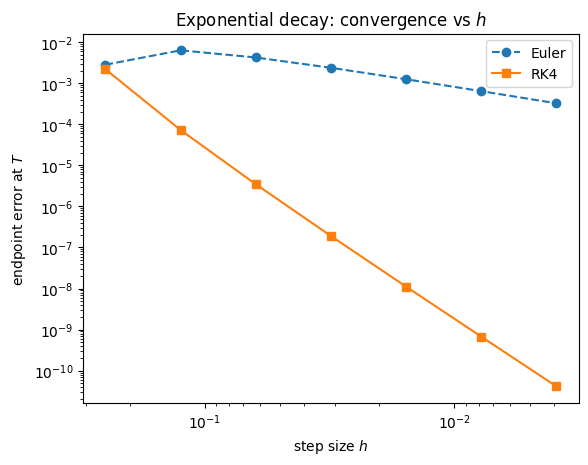

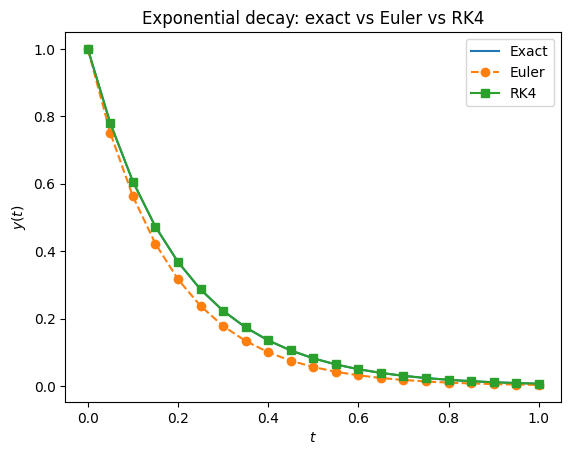

```python
import numpy as np
import matplotlib.pyplot as plt

# model & exact
lam = 5.0
def f_decay(t, y):
    return -lam * y

def exact_decay(t):
    return np.exp(-lam * t)

# experiment settings
T = 1.0
h_list = np.array([2.0**(-k) for k in range(2, 9)])

e_euler, e_rk4 = [], []

for h in h_list:
    n = int(np.ceil(T / h))
    h_eff = T / n              # land exactly on T
    tE, yE = euler(f_decay, 0.0, 1.0, T, h_eff)
    tR, yR = rk4(  f_decay, 0.0, 1.0, T, h_eff)
    yT = exact_decay(T)
    e_euler.append(abs(yE[-1] - yT))
    e_rk4.append(abs(yR[-1] - yT))

# log–log error plot
plt.figure()
plt.loglog(h_list, e_euler, 'o--', label='Euler')
plt.loglog(h_list, e_rk4,   's-',  label='RK4')
plt.gca().invert_xaxis()
plt.xlabel('step size $h$'); plt.ylabel('endpoint error at $T$')
plt.title('Exponential decay: convergence vs $h$')
plt.legend(); plt.show()

# representative trajectory (moderate h)
h = 0.05
n = int(np.ceil(T / h))
h_eff = T / n
tE, yE = euler(f_decay, 0.0, 1.0, T, h_eff)
tR, yR = rk4(  f_decay, 0.0, 1.0, T, h_eff)
tt = tE
yy = exact_decay(tt)

plt.figure()
plt.plot(tt, yy, '-',  label='Exact')
plt.plot(tE, yE, 'o--', label='Euler')
plt.plot(tR, yR, 's-',  label='RK4')
plt.xlabel('$t$'); plt.ylabel('$y(t)$')
plt.title('Exponential decay: exact vs Euler vs RK4')
plt.legend(); plt.show()
```

**Observation:** On the log–log plot, Euler’s slope is approximately $1$ (first order), while RK4’s is approximately $4$ (fourth order). In the trajectory plot, RK4 tracks the exact curve closely; Euler lags due to its single-slope approximation per step.

### 4.2 Logistic Equation

Exact solution: $$ y(t) = \frac{K}{1 + C e^{-rt}}, \qquad C = \frac{K - y_0}{y_0}. $$

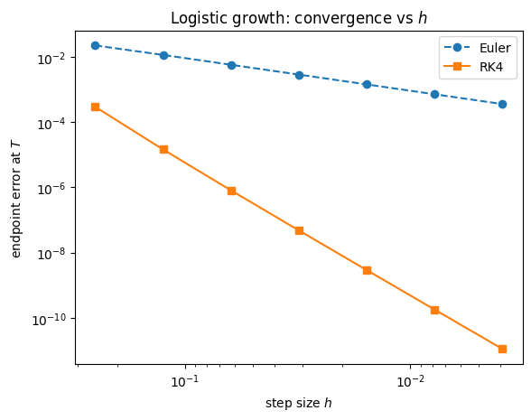

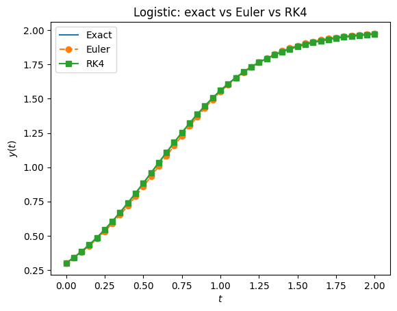

```python
# parameters & exact
r, K, y0 = 3.0, 2.0, 0.3

def f_logistic(t, y):
    return r * y * (1.0 - y / K)

def exact_logistic(t):
    C = (K - y0) / y0
    return K / (1.0 + C * np.exp(-r * t))

# experiment settings
T = 2.0
h_list = np.array([2.0**(-k) for k in range(2, 9)])

e_euler, e_rk4 = [], []

for h in h_list:
    n = int(np.ceil(T / h))
    h_eff = T / n
    tE, yE = euler(f_logistic, 0.0, y0, T, h_eff)
    tR, yR = rk4(  f_logistic, 0.0, y0, T, h_eff)
    yT = exact_logistic(T)
    e_euler.append(abs(yE[-1] - yT))
    e_rk4.append(abs(yR[-1] - yT))

# log–log error plot
plt.figure()
plt.loglog(h_list, e_euler, 'o--', label='Euler')
plt.loglog(h_list, e_rk4,   's-',  label='RK4')
plt.gca().invert_xaxis()
plt.xlabel('step size $h$'); plt.ylabel('endpoint error at $T$')
plt.title('Logistic growth: convergence vs $h$')
plt.legend(); plt.show()

# representative trajectory
h = 0.05
n = int(np.ceil(T / h))
h_eff = T / n
tE, yE = euler(f_logistic, 0.0, y0, T, h_eff)
tR, yR = rk4(  f_logistic, 0.0, y0, T, h_eff)
tt = tE
yy = exact_logistic(tt)

plt.figure()
plt.plot(tt, yy, '-',  label='Exact')
plt.plot(tE, yE, 'o--', label='Euler')
plt.plot(tR, yR, 's-',  label='RK4')
plt.xlabel('$t$'); plt.ylabel('$y(t)$')
plt.title('Logistic: exact vs Euler vs RK4')
plt.legend(); plt.show()
```

### 4.3 Harmonic Oscillator:

$$ y’ = v, \qquad v’ = -\omega^2 y. $$ The exact solution (for $y(0)=y_0$, $v(0)=v_0$) is $$ y(t) = y_0 \cos(\omega t) + \frac{v_0}{\omega}\sin(\omega t), \qquad v(t) = -\omega y_0 \sin(\omega t) + v_0 \cos(\omega t). $$ The Energy function is defined as: $$ E(t) = \tfrac{1}{2},v(t)^2 + \tfrac{1}{2},\omega^2 y(t)^2, $$ which should be constant for the exact solution.

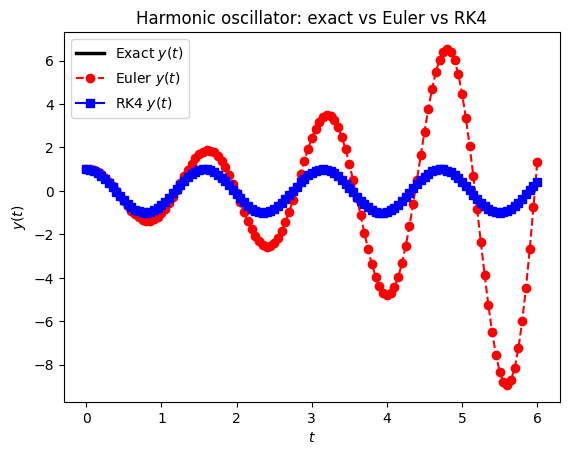

```python
# system solvers (vector state)
def euler_system(f, t0, y0_vec, T, h):
    t = t0
    y = np.array(y0_vec, dtype=float)
    ts = [t]; Ys = [y.copy()]
    n_steps = int(np.ceil((T - t0) / h))
    h_eff = (T - t0) / n_steps
    for _ in range(n_steps):
        y = y + h_eff * np.asarray(f(t, y))
        t = t + h_eff
        ts.append(t); Ys.append(y.copy())
    return np.array(ts), np.vstack(Ys)

def rk4_system(f, t0, y0_vec, T, h):
    t = t0
    y = np.array(y0_vec, dtype=float)
    ts = [t]; Ys = [y.copy()]
    n_steps = int(np.ceil((T - t0) / h))
    h_eff = (T - t0) / n_steps
    for _ in range(n_steps):
        k1 = np.asarray(f(t, y))
        k2 = np.asarray(f(t + 0.5*h_eff, y + 0.5*h_eff*k1))
        k3 = np.asarray(f(t + 0.5*h_eff, y + 0.5*h_eff*k2))
        k4 = np.asarray(f(t + h_eff,     y + h_eff*k3))
        y = y + (h_eff/6.0)*(k1 + 2*k2 + 2*k3 + k4)
        t = t + h_eff
        ts.append(t); Ys.append(y.copy())
    return np.array(ts), np.vstack(Ys)


omega = 4.0
def f_osc(t, Y):
    y, v = Y
    return np.array([v, -omega**2 * y], dtype=float)

def exact_osc(t, y0, v0):
    y = y0*np.cos(omega*t) + (v0/omega)*np.sin(omega*t)
    v = -omega*y0*np.sin(omega*t) + v0*np.cos(omega*t)
    return y, v

def energy(y, v):
    return 0.5*v**2 + 0.5*(omega**2)*y**2

# settings
y0, v0 = 1.0, 0.0
T = 6.0

# representative step
h = 0.05
tE, YE = euler_system(f_osc, 0.0, [y0, v0], T, h)
tR, YR = rk4_system(  f_osc, 0.0, [y0, v0], T, h)

# exact on same grid
tt = tE
yy, vv = exact_osc(tt, y0, v0)

# plots:
plt.figure()
plt.plot(tt, yy, '-', color='black', linewidth=2.5, label='Exact $y(t)$')
plt.plot(tE, YE[:,0], 'o--', color='red', label='Euler $y(t)$')
plt.plot(tR, YR[:,0], 's-', color='blue', label='RK4 $y(t)$')
plt.xlabel('$t$'); plt.ylabel('$y(t)$')
plt.title('Harmonic oscillator: exact vs Euler vs RK4')
plt.legend(); plt.show()

EE_exact = energy(yy, vv)
EE_euler = energy(YE[:,0], YE[:,1])
EE_rk4   = energy(YR[:,0], YR[:,1])
```

## 5. Summary

In this notebook, I compared exact analytic solutions of differential equations with two numerical integration schemes: the Forward Euler method and the Runge–Kutta method of order four (RK4). Euler’s method follows directly from the definition of the derivative, but its local linear approximation leads to noticeable error accumulation and, in some cases, instability. RK4, on the other hand, evaluates the slope several times within each step, producing a higher-order approximation that is far more accurate for the same step size.

Across the examples : exponential decay, logistic growth, and the harmonic oscillator — we observed a consistent pattern: Euler captures the qualitative direction of change but may distort the scale or stability of the system, while RK4 preserves both magnitude and behavior much more faithfully. When an analytic solution is available, numerical methods can be evaluated directly; when not, this comparison highlights the importance of understanding the structure of the underlying system and choosing methods accordingly.